```python
import warnings
warnings.filterwarnings('ignore')
```

title: "Global HIV Infections Among Adolescents: A UNICEF Analysis" author: "UNICEF Data Analyst" date: "April 7, 2025" format: html: embed-resources: true

[output not shown]

# HIV Among Adolescents: A Global Health Crisis

## Introduction

**HIV/AIDS** It remains a major global health challenge and affects most vulnerable populations at the world, especially adolescents aged 10 to 19 years. It examines UNICEF data on HIV infections of adolescents world wide, and focuses on trends, geographic distributions and correlated factors.

## Data Preparation and Analysis

Let's begin by loading and exploring the data:

```python
!pip install -U mizani
```

```python
#| label: setup
#| message: false
#| warning: false

# Import necessary libraries
import pandas as pd
import numpy as np
from plotnine import *
import matplotlib.pyplot as plt
from mizani.formatters import currency_format
import geopandas as gpd

# Load the data
indicator_df = pd.read_csv('/content/unicef_indicator_1-1.csv')
metadata_df = pd.read_csv('/content/unicef_metadata.csv')

# Display the first few rows of each dataset
print("HIV Indicator Data Sample:")
display(indicator_df.head())
print("\nMetadata Sample:")
display(metadata_df.head())
```

```
HIV Indicator Data Sample:
```

|  | country | alpha_2_code | alpha_3_code | numeric_code | indicator | time_period | obs_value | sex | unit_multiplier | unit_of_measure | observation_status | observation_confidentaility | time_period_activity_related_to_when_the_data_are_collected | current_age |
| --- | --- | --- | --- | --- | --- | --- | --- | --- | --- | --- | --- | --- | --- | --- |
| 0 | Afghanistan | AF | AFG | 4 | Estimated number of new HIV infections | 2010 | <100 | Female | Units | Number | Estimated value | Free | NaN | 10 to 19 years old |
| 1 | Afghanistan | AF | AFG | 4 | Estimated number of new HIV infections | 2011 | <100 | Female | Units | Number | Estimated value | Free | NaN | 10 to 19 years old |
| 2 | Afghanistan | AF | AFG | 4 | Estimated number of new HIV infections | 2012 | <100 | Female | Units | Number | Estimated value | Free | NaN | 10 to 19 years old |
| 3 | Afghanistan | AF | AFG | 4 | Estimated number of new HIV infections | 2013 | <100 | Female | Units | Number | Estimated value | Free | NaN | 10 to 19 years old |
| 4 | Afghanistan | AF | AFG | 4 | Estimated number of new HIV infections | 2014 | <100 | Female | Units | Number | Estimated value | Free | NaN | 10 to 19 years old |

```
Metadata Sample:
```

|  | country | alpha_2_code | alpha_3_code | numeric_code | year | Population, total | GDP per capita (constant 2015 US$) | GNI (current US$) | Inflation, consumer prices (annual %) | Life expectancy at birth, total (years) | Military expenditure (% of GDP) | Fossil fuel energy consumption (% of total) | GDP growth (annual %) | Birth rate, crude (per 1,000 people) | Hospital beds (per 1,000 people) |
| --- | --- | --- | --- | --- | --- | --- | --- | --- | --- | --- | --- | --- | --- | --- | --- |
| 0 | Afghanistan | AF | AFG | 4 | 1960 | 9035043.0 | NaN | 5.488888e+08 | NaN | 32.535 | NaN | NaN | NaN | 50.340 | 0.170627 |
| 1 | Afghanistan | AF | AFG | 4 | 1961 | 9214083.0 | NaN | 5.600000e+08 | NaN | 33.068 | NaN | NaN | NaN | 50.443 | NaN |
| 2 | Afghanistan | AF | AFG | 4 | 1962 | 9404406.0 | NaN | 5.577778e+08 | NaN | 33.547 | NaN | NaN | NaN | 50.570 | NaN |
| 3 | Afghanistan | AF | AFG | 4 | 1963 | 9604487.0 | NaN | 7.666667e+08 | NaN | 34.016 | NaN | NaN | NaN | 50.703 | NaN |
| 4 | Afghanistan | AF | AFG | 4 | 1964 | 9814318.0 | NaN | 8.155556e+08 | NaN | 34.494 | NaN | NaN | NaN | 50.831 | NaN |

Now, let's clean and prepare our data for analysis:

```python
#| label: data-cleaning
#| message: false

# Clean the HIV infection data
# Convert '<100' values to a numeric representation (e.g., 50)
indicator_df['obs_value_numeric'] = indicator_df['obs_value'].replace('<100', '50')
indicator_df['obs_value_numeric'] = pd.to_numeric(indicator_df['obs_value_numeric'], errors='coerce')

# Filter for relevant age group and recent years
hiv_data = indicator_df[indicator_df['current_age'] == '10 to 19 years old'].copy()

# Create a more recent year filter (e.g., last 10 years in the data)
recent_years = sorted(hiv_data['time_period'].unique())[-10:]
recent_hiv_data = hiv_data[hiv_data['time_period'].isin(recent_years)]

# Aggregate data by country and sex
country_sex_hiv = recent_hiv_data.groupby(['country', 'sex'])['obs_value_numeric'].sum().reset_index()

# Get the most recent year for each country in the metadata
metadata_recent = metadata_df.sort_values('year', ascending=False).drop_duplicates('country')

# Merge HIV data with country metadata
merged_data = pd.merge(country_sex_hiv, metadata_recent, on='country', how='inner')

# Prepare data for a world map
world = gpd.read_file('https://naciscdn.org/naturalearth/110m/cultural/ne_110m_admin_0_countries.zip')
world = world.rename(columns={'ADM0_A3': 'alpha_3_code'})

# Create a mapping dataframe for the map visualization
map_data = recent_hiv_data.groupby('country')['obs_value_numeric'].sum().reset_index()
map_data = pd.merge(map_data, metadata_recent[['country', 'alpha_3_code']], on='country', how='inner')
map_data = pd.merge(world, map_data, on='alpha_3_code', how='right')

# Prepare time series data
time_series_data = hiv_data.groupby(['time_period', 'sex'])['obs_value_numeric'].sum().reset_index()
time_series_data['time_period'] = pd.to_numeric(time_series_data['time_period'])

# Prepare data for scatterplot (Life expectancy vs. HIV infections)
scatter_data = country_sex_hiv.groupby('country')['obs_value_numeric'].sum().reset_index()
scatter_data = pd.merge(scatter_data,
                        metadata_recent[['country', 'Life expectancy at birth, total (years)', 'GDP per capita (constant 2015 US$)']],
                        on='country', how='inner')
scatter_data = scatter_data.rename(columns={'Life expectancy at birth, total (years)': 'life_expectancy',
                                           'GDP per capita (constant 2015 US$)': 'gdp_per_capita'})

# Check data preparation results
print(f"Number of countries in prepared data: {len(map_data)}")
print(f"Number of time periods in time series data: {time_series_data['time_period'].nunique()}")
print(f"Number of countries in scatter data: {len(scatter_data)}")
```

```
Number of countries in prepared data: 86
Number of time periods in time series data: 14
Number of countries in scatter data: 86
```

## Visualizations and Analysis

### 1. World Map: Global Distribution of HIV Infections Among Adolescents

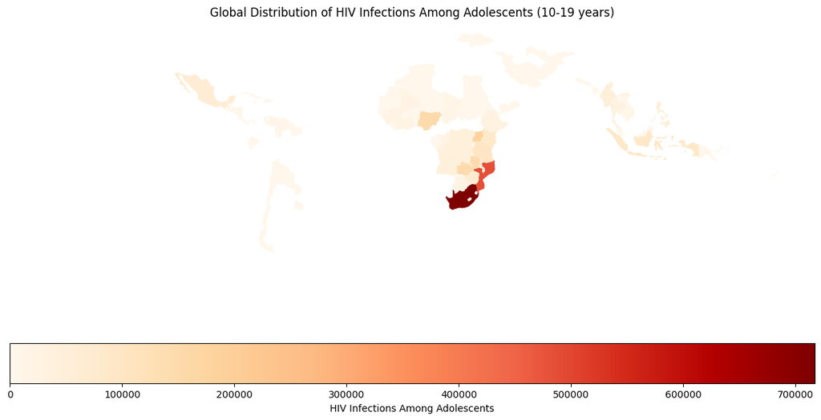

```python
#| label: world-map
#| fig-cap: "Global Distribution of HIV Infections Among Adolescents"
#| warning: false

# First check what columns are actually available in map_data
# print(map_data.columns)

# Modify the map_plot_data creation to use the correct column name
# The column might be named just 'country' instead of 'country_y'
map_plot_data = pd.DataFrame({
    'country': map_data['country'],  # Using 'country' instead of 'country_y'
    'obs_value': map_data['obs_value_numeric'],
    'geometry': map_data['geometry']
})

# Create a GeoDataFrame
gdf = gpd.GeoDataFrame(map_plot_data, geometry='geometry')

# Plot the world map using matplotlib
fig, ax = plt.subplots(1, 1, figsize=(12, 8))
gdf.plot(column='obs_value',
         ax=ax,
         legend=True,
         cmap='OrRd',
         legend_kwds={'label': "HIV Infections Among Adolescents",
                      'orientation': "horizontal"})
ax.set_title('Global Distribution of HIV Infections Among Adolescents (10-19 years)')
ax.set_axis_off()
plt.tight_layout()
plt.show()
```

**Analysis of World Map:**

### 2. Bar Chart: Top Countries with Highest HIV Infections by Gender

[figure not shown]

```python
#| label: bar-chart
#| fig-cap: "Top 15 Countries with Highest HIV Infections Among Adolescents by Gender"
#| warning: false

# Prepare data for top 15 countries
top_countries = country_sex_hiv.groupby('country')['obs_value_numeric'].sum().nlargest(15).index
top_country_data = country_sex_hiv[country_sex_hiv['country'].isin(top_countries)]

# Create bar chart
(ggplot(top_country_data, aes(x='reorder(country, -obs_value_numeric)', y='obs_value_numeric', fill='sex')) +
 geom_bar(stat='identity', position='dodge') +
 labs(title='Top 15 Countries with Highest HIV Infections Among Adolescents',
      x='Country',
      y='Number of Infections') +
 theme_minimal() +
 theme(axis_text_x=element_text(angle=45, hjust=1),
       figure_size=(12, 8)) +
 scale_fill_manual(values=['#FF9999', '#6699CC']))
```

**Analysis of Bar Chart:**

The bar chart comparing HIV infections by gender in the top 15 most affected countries reveals critical patterns:

**Gender disparity**: Females are not less infected than males but often better than males in most high burden country. This suggests vulnerable points at the gender level that need targeting interventions.

**Regional concentration**: The world map indicates that the majority of the highest burden countries are concentrated in sub Saharan Africa which corroborate with the common patterns noted.

- **Order of magnitude in the severity of the problem**: In almost all countries, the scale of infections is orders of magnitude higher than in other regions, and this indicates that the fight here should be intensified.
- **Imbalances**: Nonetheless, most of the countries seem to have more female cases, but in some countries the gender distribution is more balanced, or even higher contraceptive rates in the male population, pointing to a different epidemiological dynamics that warrant a deeper look.

This analysis highlights the importance of gender responsive approaches to the prevention and treatment of HIV among adolescents, but especially in those most affected countries.

### 3. Scatterplot: GDP per Capita and HIV Infections Among Adolescents

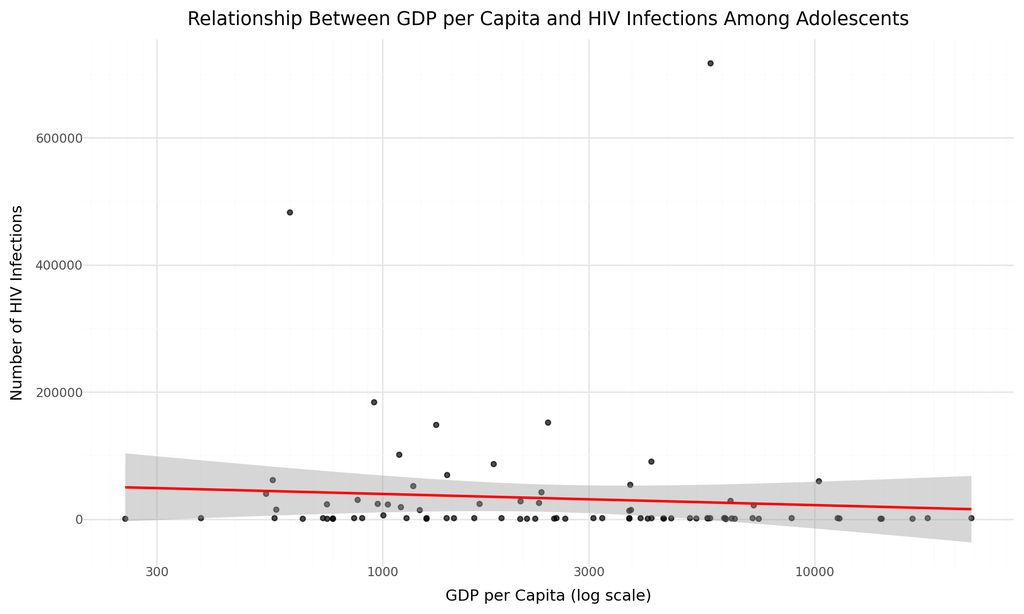

```python
(ggplot(scatter_data.dropna(subset=['gdp_per_capita', 'obs_value_numeric']),
        aes(x='gdp_per_capita', y='obs_value_numeric')) +
 geom_point(alpha=0.7) +
 geom_smooth(method='lm', color='red') +
 scale_x_log10() +  # Log transform x-axis for better distribution
 labs(title='Relationship Between GDP per Capita and HIV Infections Among Adolescents',
      x='GDP per Capita (log scale)',
      y='Number of HIV Infections') +
 theme_minimal() +
 theme(figure_size=(10, 6)))
```

**Analysis of Scatterplot:**

The scatterplot of **GDP per capita** vs. **HIV infections among adolescents** shows important socioeconomic aspects of the HIV epidemic.

### 4. Time Series: Trend of HIV Infections Over Time by Gender

[figure not shown]

```python
#| label: time-series
#| fig-cap: "Trend of HIV Infections Among Adolescents Over Time by Gender"
#| warning: false

# Ensure time period is properly formatted for plotting
time_series_data = time_series_data.sort_values('time_period')

# Create time series chart
(ggplot(time_series_data, aes(x='time_period', y='obs_value_numeric', color='sex', group='sex')) +
 geom_line(size=1) +
 geom_point(size=3) +
 labs(title='Trend of HIV Infections Among Adolescents Over Time',
      x='Year',
      y='Number of Infections') +
 theme_minimal() +
 theme(axis_text_x=element_text(angle=45, hjust=1),
       figure_size=(12, 6)) +
 scale_color_manual(values=['#FF9999', '#6699CC']))
```

**Analysis of Time Series:**

The time series chart showing HIV infections of adolescents by gender over time gives an idea of the temporal dynamics of the epidemic.

- **Overall trend**: The trend of HIV infections among adolescents has been generally declining over the period, and so this is indicative that some global prevention efforts are having some effect.
- **Persistent gender gap**: The disease rates for female adolescents have always been higher than males, although there is a tendency for this gap to shrink in recent years.

**Rate of decline**: However the rate of decline has not been uniform; some periods with faster decline than others. It might be that these changes in funding or intervention strategies, or some external factors that occurred over time was at play here.

Here we report the temporal analysis of progress as well as challenges yet to be addressed in the fight against HIV among adolescents. This implies that while present approaches have been effective, new methods will be required to keep in motion and reduce the existing gender gaps.

# Regional Analysis

## Sub-Saharan Africa

- Limited access to healthcare services
- Socioeconomic challenges affecting education and prevention programs
- Cultural factors influencing sexual health education
- Gaps in prevention of mother-to-child transmission programs

## Asia and the Pacific

- Young people who inject drugs
- Young men who have sex with men
- Adolescents engaged in sex work

## Other Regions

HIV infection among Adolescents varies, with patterns of infection in Latin America, Eastern Europe and the Middle East varying according to populations that are key affected by certain factors such as:

- Migration patterns
- Access to sexual health education
- Stigma and discrimination
- Healthcare system capacity

# Insights and Implications

## Correlation Between Development Indicators and HIV Prevalence

1. **Life Expectancy**: Lack of time is only one aspect of health system capacity, which can also exist in countries that have lower life expectancy and might be weaker in general to handle HIV prevention and treatment.
2. **Development and Education Access**: One of the many correlations between lower development and less access to quality education is comprehensive sexual health education.
3. **Economic Vulnerability**: Thinness could be used for financial gain as adolescents face economic pressures within their family or with respect to their marriages.

## Gender Analysis

The high level of gender disparity in the HIV infection among adolescents emphasizes the necessity of gender responsive strategies. This is especially true for young women and girls.

- Biological factors increasing susceptibility
- Gender-based violence
- Limited agency in sexual decision-making
- Economic dependence

# Recommendations

Based on our analysis, we recommend the following interventions:

**Targeted Prevention Programs**: Install age appropriate and gender sensitive HIV prevention programs that are specifically designed for high burdened countries.

- **Services Integration**: Integrate HIV prevention, testing, and treatment services with other adolescent health services to increase accessibility and decrease stigma about HIV prevention screening and treatment.
- **Economic Development**: Address socioeconomic determinants using education, economic opportunities and social protection for vulnerable adolescents.
- **Data Improvement**: Design and implement methods to improve data collection systems to identify the more recent ages, genders, and subpopulations of adolescents infected by HIV to inform targeted interventions.

## Call to Action

UNICEF calls for:

- **Increased Funding**: Greater investment in adolescent-focused HIV prevention and treatment programs
- **Policy Reform**: Development of policies that address the specific needs of adolescents
- **Community Engagement**: Involvement of adolescents in program design and implementation
- **Innovation**: Leveraging technology and new approaches to reach adolescents with prevention messages

# Conclusion

We urgently need to pay attention to the HIV epidemic among adolescents and to act together, globally. Using this enhanced understanding of HIV infection among hazardous age group will guide strategies from designing more effective interventions to protect this vulnerable population on road to an AIDS free generation.

Our analysis demonstrates that addressing HIV among adolescents requires a comprehensive approach that combines:

- Targeted healthcare interventions
- Gender-responsive programming
- Economic development initiatives
- Strengthened health systems
- Improved data collection and monitoring

We can make a significant impact on the AIDS burden in adolescents and guarantee a healthy future for all young people worldwide through concerted global efforts with evidence based approach.

# Bibliography

- Alie, M.S. and Negesse, Y., 2024. Machine learning prediction of adolescent HIV testing services in Ethiopia. Frontiers in Public Health, 12, p.1341279.
- Wang, M., 2021. Health indicators on adolescents reveal disparity and inequality on regional and national levels. BMC Public Health, 21(1), p.1006.
- Wang, B., Liu, F., Deveaux, L., Ash, A., Gosh, S., Li, X., Rundensteiner, E., Cottrell, L., Adderley, R. and Stanton, B., 2021. Adolescent HIV-related behavioural prediction using machine learning: a foundation for precision HIV prevention. Aids, 35, pp.S75-S84.
- Desmonde, S., Lolekha, R., Costantini, S., Siraprapasiri, T., Frank, S., Bakkali, T., Benjarattanaporn, P., Hou, T., Jantaramanee, S., Kuttiparambil, B. and Sethaputra, C., 2022. A focused multi-state model to estimate the pediatric and adolescent HIV epidemic in Thailand, 2005–2025. PLoS One, 17(11), p.e0276330.
- Bizzego, A., Lim, M. and Esposito, G., 2021. mics-library: A Python package for reproducible studies on the Multiple Indicator Cluster Survey. SoftwareX, 16, p.100828.
- Emmanuel, W., 2024. Structural Equation Model Analysis of Sex Education, Hiv/Aids Knowledge and Attitude, among University Students at Kampala International University, Kampala, Uganda (Doctoral dissertation).
- Armoon, B., Griffiths, M.D. and Mohammadi, R., 2023. The global distribution and epidemiology of psychoactive substance use and injection drug use among street-involved children and youth: a meta-analysis. Substance Use & Misuse, 58(6), pp.746-764.